# Modulation Prediction - CNN Configuration 2

### Setting up Training Data

In this section, we are importing the training and testing test set in .hdf5 format and converting them to numpy arrays.

```python
import numpy as np
import h5py
import csv
import matplotlib.pyplot as plt
with h5py.File("data.hdf5", 'r') as f:
    train_data = f['train'][()]
    test_data = f['test'][()]
labels = open('train_labels.csv')
labels_reader = csv.reader(labels)
classes = ["FM","OQPSK","BPSK","8PSK","AM-SSB-SC","4ASK","16PSK","AM-DSB-SC","QPSK","OOK"]
train_labels_data = []
for row in labels_reader:
    if row[0] != 'Id':
        train_labels_data.append(classes.index(row[1]))

train_labels_data = np.asarray(train_labels_data)
print(train_data.shape)
print(len(train_labels_data))
print(test_data.shape)
```

```
(30000, 1024, 2)
30000
(20000, 1024, 2)
```

### Data Augmentation

```python
counter = 0
for i in train_data:
    print(counter)
    if counter > 4000:
        break
    # rotation matrix
    theta = np.pi/2
    rot = np.array([[np.cos(theta), -1*np.sin(theta)],[np.sin(theta),np.cos(theta)]])
    np.append(train_data,np.dot(rot,i.transpose()).transpose())
    np.append(train_labels_data,train_labels_data[counter])

    theta = np.pi
    rot = np.array([[np.cos(theta), -1*np.sin(theta)],[np.sin(theta),np.cos(theta)]])
    np.append(train_data,np.dot(rot,i.transpose()).transpose())
    np.append(train_labels_data,train_labels_data[counter])
    counter+=1

train_data
```

[output not shown]

[output cut: 3947 more lines]

[output not shown]

```
array([[[ 0.81229824,  0.35837647],
        [ 1.5064487 ,  0.32473826],
        [-1.3345141 , -0.11483677],
        ...,
        [ 0.4622633 ,  0.00232144],
        [-0.44701815,  0.3409667 ],
        [ 0.0929121 , -1.250979  ]],

       [[ 0.8651555 ,  1.1208268 ],
        [ 0.93955   ,  1.0812321 ],
        [ 1.0046352 ,  0.9699535 ],
        ...,
        [-0.17610398, -0.0531827 ],
        [-0.0274519 ,  0.10420295],
        [ 0.05284544,  0.23353934]],

       [[-0.27755857,  0.47558302],
        [ 0.269747  , -0.36386353],
        [ 0.7656934 , -0.3021099 ],
        ...,
        [-0.44257054,  0.25459397],
        [-0.93191254, -0.61050004],
        [ 0.5299933 ,  0.09297071]],

       ...,

       [[-1.2948849 ,  0.8575006 ],
        [-0.52819824, -0.70112824],
        [-0.8181306 ,  0.5288491 ],
        ...,
        [-0.34768716,  0.4826538 ],
        [ 0.14753036,  0.7205618 ],
        [-0.7184609 , -0.23059411]],

       [[-0.20838957,  0.28949115],
        [-1.2750533 ,  0.2082836 ],
        [-0.995211  ,  0.16588576],
        ...,
        [ 0.4434878 , -0.6900661 ],
        [-0.05305082,  0.05295856],
        [ 0.14935887,  0.1882925 ]],

       [[-0.2306667 , -0.42676774],
        [ 0.9506056 , -0.09998692],
        [-0.02584958,  0.3617045 ],
        ...,
        [-0.9461389 ,  0.84369624],
        [ 0.6568758 ,  0.04648934],
        [-0.66253257,  0.1033797 ]]], dtype=float32)
```

### Visualizing Data

In order to get a sense for the "patterns" of the different labels, we will plot the first 10 samples from the training set. The X-axis will be the interphase component while the quadrature component is on the Y-axis. Each training sample has 1024 points with I/Q coordinates.

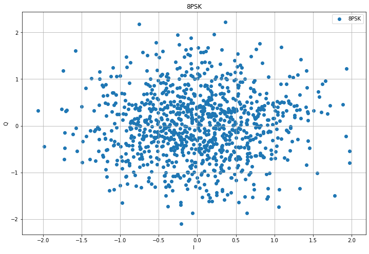

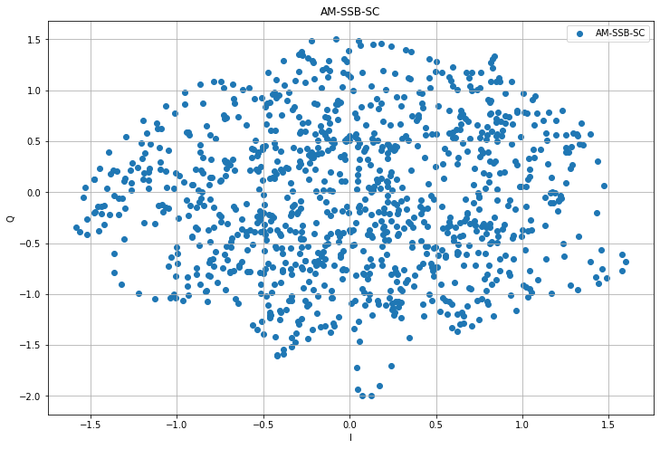

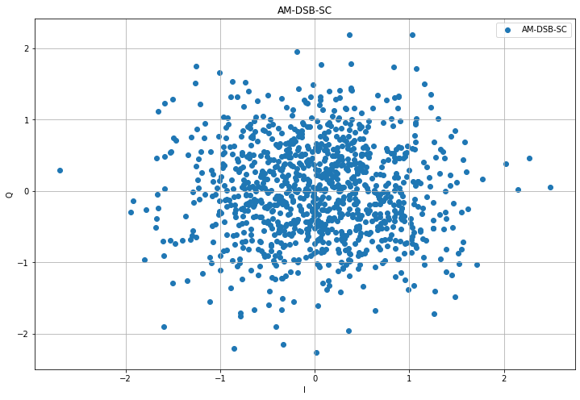

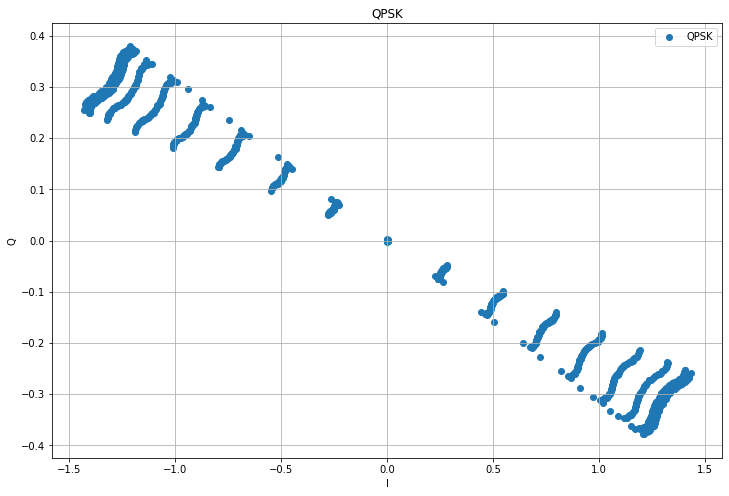

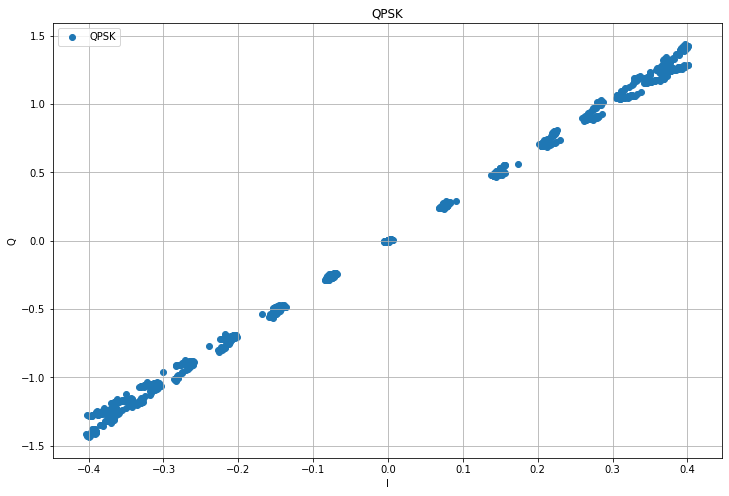

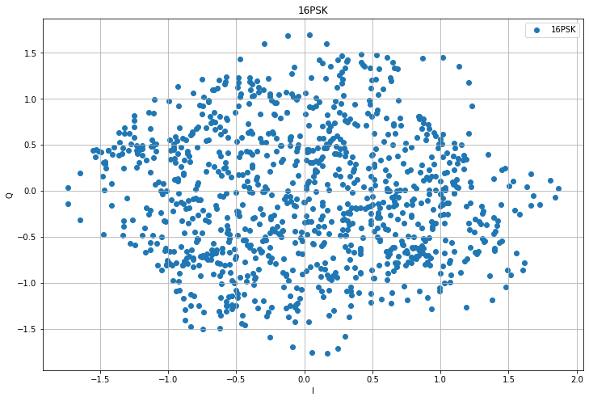

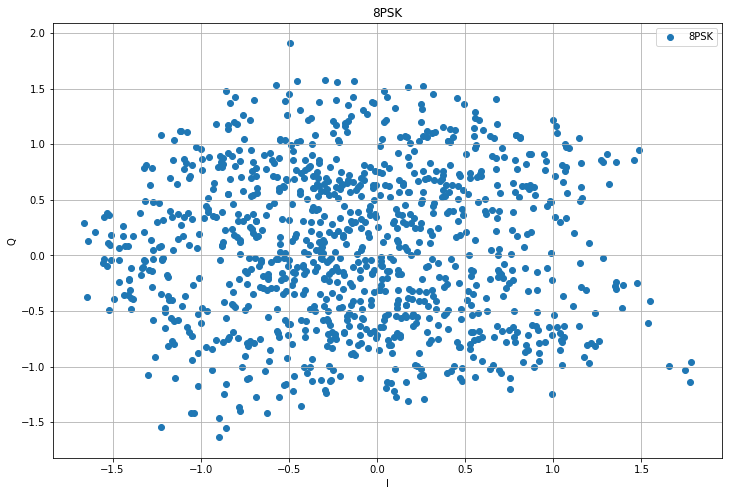

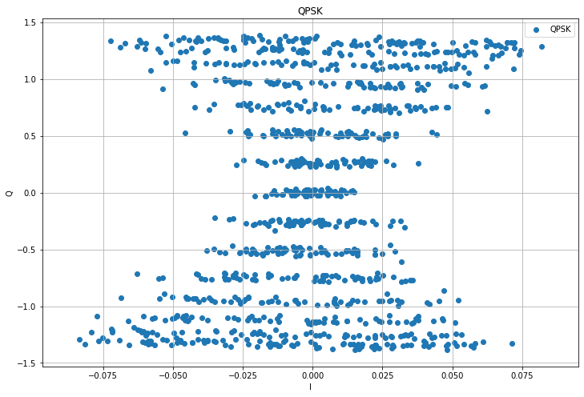

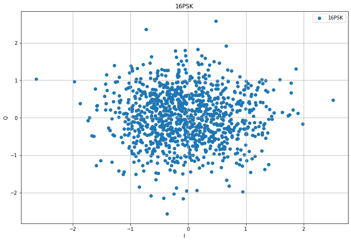

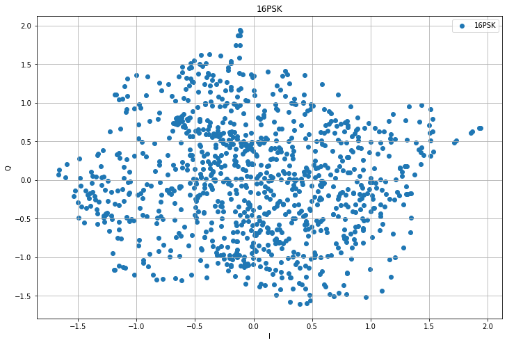

```python
for j in range(0,10):
    I = []
    Q = []
    for i in range(0,1024):
        I.append(train_data[j][i][0])
        Q.append(train_data[j][i][1])

    plt.figure(j, figsize=(12, 8))
    plt.scatter(I,Q, label=classes[train_labels_data[j]])
    plt.title(classes[train_labels_data[j]])
    plt.xlabel('I')
    plt.ylabel('Q')
    plt.legend(loc='best')
    plt.grid()
    plt.show()
```

### Training and Testing Splitting

In this section, we are converting the training and testing sets into Torch tensor format. After that I have split the training set into several smaller segments. I did this because I wanted to experiment with the batch size and analyze how it affects overfitting/underfitting. In addition, a validation set was created in order to see if the model is overfitting/underfitting during training.

```python
from __future__ import print_function
import torch
from torch.nn import Linear, ReLU, CrossEntropyLoss, Sequential, Conv2d, MaxPool2d, Module, Softmax, BatchNorm2d, Dropout
from torch.optim import Adam, SGD
from torch.autograd import Variable
import torch.nn.functional as F
from sklearn.metrics import accuracy_score
from sklearn.model_selection import train_test_split
import torchvision
from torchvision import datasets, transforms

# converting training images into torch format
train_x = train_data.reshape(30000, 1, 1024, 2)
train_x  = torch.from_numpy(train_x)

# train_fft_x = fft_train_2d.reshape(30000, 1, 1024, 2)
# train_fft_x  = torch.from_numpy(train_fft_x)

# converting test images into torch format
test_x = test_data.reshape(20000, 1, 1024, 2)
test_x  = torch.from_numpy(test_x)

# converting the target into torch format
train_y = train_labels_data.astype(int)
train_y = torch.from_numpy(train_y)


# split into batches
train_x, val_x, train_y, val_y = train_test_split(train_x, train_y, test_size = 0.3,shuffle=True)

train_x1, train_x2, train_y1,train_y2 = train_test_split(train_x, train_y, test_size = 0.50,shuffle=True)
train_x3, train_x4, train_y3,train_y4 = train_test_split(train_x1, train_y1, test_size = 0.50,shuffle=True)
train_x5, train_x6, train_y5,train_y6 = train_test_split(train_x2, train_y2, test_size = 0.7,shuffle=True)
train_val1, train_val2, train_valy1,train_valy2 = train_test_split(val_x, val_y, test_size = 0.95,shuffle=True)
# batches
train = torch.utils.data.TensorDataset(train_x,train_y)
trainloader = torch.utils.data.DataLoader(train, batch_size=240, shuffle=True)

# shape of training data
print(train_x.shape)
print(train_y.shape)
```

[output not shown]

### Setting up Convolutional Neural Network Architecture

In this section, we are specifying the Convolutional Neural Network Architecture for classification. For the framework, I have decided to use PyTorch, as it is relatively lightweight. This specific Jupyter Notebook is for one of two configurations of my CNN. In this configuration, I have used 3 convolution layers, followed by 2 fully-connected layers. In addition, I have used batch normalization for the all 3 convolution layers to reduce covariate shift within the network. A combination of SELU and RELU activations were used.

Convolution layers: (1) 128 filters, 3X1 kernel size, Stride of 1 (2) 64 filters, 3x2 kernel size, Stide of 1 (3) 64 filters, 3x1 kernel size, Stide of 1

Fully-connected: (1) 65152 neurons to 128 neurons (2) 128 to 10 neurons

```python
import torch.nn as nn

class Net2(nn.Module):
    def __init__(self):
        super(Net2, self).__init__()
        self.conv1 = nn.Conv2d(1, 128, kernel_size=(3,1), stride=1)
        self.batchnorm1 = nn.BatchNorm2d(num_features=128)
        self.batchnorm2 = nn.BatchNorm2d(num_features=64)
        self.conv2 = nn.Conv2d(128, 64, kernel_size=(3,2), stride=1)
        self.conv3 = nn.Conv2d(64, 64, kernel_size=(3,1), stride=1)
        self.fc1 = nn.Linear(65152, 128)
        self.fc2 = nn.Linear(128, len(classes))

    def forward(self, x):
        x = F.relu(self.batchnorm1(self.conv1(x)))
        x = F.relu(self.batchnorm2(self.conv2(x)))
        x = F.selu(self.batchnorm2(self.conv3(x)))
        x = x.view(-1, 65152)
        x = F.relu(self.fc1(x))
        x = self.fc2(x)
        return F.log_softmax(x, dim=1)

cnn = Net2()
print(cnn)

it = iter(trainloader)

#calculate dimensions
x = torch.randn(3,1,1024,2)
conv1 = nn.Conv2d(1, 128, kernel_size=(3,1), stride=1)
y=conv1(x)
print(y.shape)
conv2 = nn.Conv2d(128, 64, kernel_size=(3,2), stride=1)
y=conv2(y)
print(y.shape)
conv3 = nn.Conv2d(64, 64, kernel_size=(3,1), stride=1)
y=conv3(y)
print(y.shape)
#65152
```

[output not shown]

### Set up training protocol

```python
def fit(model, train_loader,trainacc,trainloss,testacc):
    optimizer = torch.optim.Adagrad(model.parameters(),lr=0.0002, weight_decay=0.00007 )
    error = nn.CrossEntropyLoss()
    EPOCHS = 20
    model.train()
    for epoch in range(EPOCHS):
        for batch_idx, (X_batch, y_batch) in enumerate(train_loader):
            var_X_batch = Variable(X_batch).float()
            var_y_batch = Variable(y_batch)
            optimizer.zero_grad()
            output = model(var_X_batch)
            loss = error(output, var_y_batch)
            loss.backward()
            optimizer.step()
            predicted = torch.max(output.data, 1)[1]
            print("Accuracy:")
            print(((predicted == var_y_batch).sum()).double()/240)
            trainacc.append((((predicted == var_y_batch).sum()).double()/240))
            print("Loss:")
            print(loss)
            trainloss.append(loss)
            print("Epoch:")
            print(epoch)
            print("Batch:")
            print(batch_idx)
            if (batch_idx % 20 == 0):
                with torch.no_grad():
                    validout = model(train_val1)
                valpred = torch.max(validout.data, 1)[1]
                print("########################")
                print("Validation Accuracy:")
                print(((valpred == train_valy1).sum()).double()/len(train_valy1))
                testacc.append((((valpred == train_valy1).sum()).double()/len(train_valy1)))
                print("########################")
```

```python
trainacc,trainloss,testacc=[],[],[]

fit(cnn,trainloader,trainacc,trainloss,testacc)
```

[output not shown]

[output cut: 14425 more lines]

```
tensor(0.9708, dtype=torch.float64)
Loss:
tensor(0.3648, grad_fn=<NllLossBackward>)
Epoch:
19
Batch:
86
Accuracy:
tensor(0.4708, dtype=torch.float64)
Loss:
tensor(0.4269, grad_fn=<NllLossBackward>)
Epoch:
19
Batch:
87
```

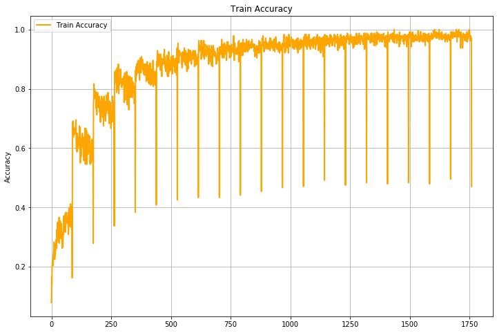

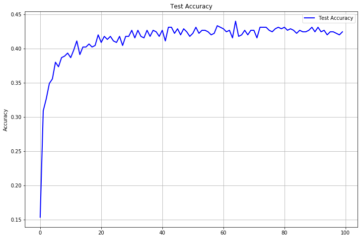

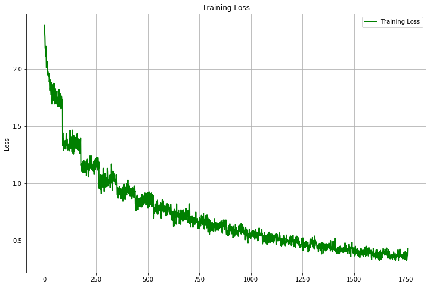

```python
plt.figure(1, figsize=(12, 8))
plt.plot(trainacc, '-', color='orange',linewidth=2, label='Train Accuracy')
plt.title('Train Accuracy')
plt.ylabel('Accuracy')
plt.legend(loc='best')
plt.grid()
plt.show()


plt.figure(2, figsize=(12, 8))
plt.plot(testacc, '-', color='blue',linewidth=2, label='Test Accuracy')
plt.title('Test Accuracy')
plt.ylabel('Accuracy')
plt.legend(loc='best')
plt.grid()
plt.show()


plt.figure(3, figsize=(12, 8))
plt.plot(trainloss, '-', color='green',linewidth=2, label='Training Loss')
plt.title('Training Loss')
plt.ylabel('Loss')
plt.legend(loc='best')
plt.grid()
plt.show()
```

### Predictions

Generating predictions for the testing set and preparing for submission.

```python
with torch.no_grad():
    output = cnn(test_x)
```

```python
prob = output.tolist()
predictions = np.argmax(prob, axis=1)

pred_label = []
for i in predictions:
    pred_label.append(classes[i])
from numpy import asarray
from numpy import savetxt
import pandas as pd
# define id
id = np.arange(0,20000)
labels=np.asarray(pred_label)
labels.reshape(20000,1)
print(labels.shape)
d = {'Category':labels}
df = pd.DataFrame(data=d)
df.to_csv('submission.csv')
```

```
(20000,)
```

[output not shown]